title: “Practice Final Part2” output: pdf_document: default html_document: null date: “Summer Semester 2020”

## Instructions

This R Markdown file includes the questions, the empty code chunk sections for your code, and the text blocks for your responses. Answer the questions below by completing the R Markdown file. You must answer the questions using this file. You can change the format from pdf to Word or html and make other slight adjustments to get the file to knit but otherwise keep the formatting the same. Once you’ve finished answering the questions, submit your responses in a single knitted file (just like the homework peer assessments).

Partial credit may be given if your code is correct but your conclusion is incorrect or vice versa.

*Next Steps:*

1. Save this `.Rmd` file in your `R` working directory, the same directory where you will download the `atlanta_flights.csv` and `echo.csv` data files into. Having all files in the same directory will help in reading the `.csv` file.
2. Read the question and create the R code necessary within the code chunk section immediately below each question. Knitting this file will generate the output and insert it into the section below the code chunk.
3. Type your answer to the questions in the text block provided immediately after the response prompt: **This is how the response prompt will be formatted**.
4. Once you’ve finished answering all questions, knit this file and submit the knitted file on Canvas.

*Example Question Format:*

(1a) This will be the exam question each question is already copied from Canvas and inserted into individual text blocks below, *you do not need to copy/paste the questions from the online Canvas exam.*

```r
# Example code chunk area. Enter your code below the comment`
```

**Response to question (1a)**: This is the section where you type your written answers to the question. Depending on the question asked, your typed response may be a number, a list of variables, a few sentences, or a combination of these elements.

**Ready? Let’s begin.**

# Part 1: Multiple Linear Regression

## Data Set Background

The data analyzed in the first part of the exam came from a sample of flights leaving the Atlanta Airport in the year 2015.

The **response variable** is ‘DEPARTURE_DELAY’ which is a continuous variable indicating the number of minutes a flight was delayed note that there are negative values, indicating that the flight in question actually departed early.

The **predicting variables** are as follows:

- DAY_OF_WEEK integer value for day of the week (Sunday=1, Monday=2, …, Saturday=7)
- AIRLINE factor variable for each airline (AA = American Airlines, AS = Alaska Airlines, DL = Delta, F9 = Frontier Airlines, MQ = American Eagle, NK = Spirit Airlines, OO = SkyWest Airlines, UA = United Airlines, US = US Airways, WN = Southwest Airlines)
- DESTINATION_AIRPORT factor variable for destination airport (unique 3 letter code for each airport; ie ATL is Atlanta, SFO is San Francisco, LGA is LaGuardia)
- SCHEDULED_DEPARTURE scheduled departure time, in military time as HHMM (so 1:45pm will appear as 1345)
- SCHEDULED_ARRIVAL scheduled arrival time, in military time as HHMM (so 1:45pm will appear as 1345)
- DISTANCE distance of flight in miles

## Read Data

Read the data and answer the questions below. Assume a *significance threshold of 0.05* for hypothesis tests.

```r
set.seed(100)
# Read the data set
atlanta_flights = read.csv('atlanta_flights.csv', header=TRUE, sep=",")

# Viewing first few rows of data
head(atlanta_flights)
```

```
##   DAY_OF_WEEK AIRLINE ORIGIN_AIRPORT DESTINATION_AIRPORT SCHEDULED_DEPARTURE
## 1           5      EV            ATL                 HNL                1050
## 2           5      DL            ATL                 HNL                1050
## 3           4      DL            ATL                 SEA                1050
## 4           5      DL            ATL                 SEA                 810
## 5           5      DL            ATL                 SEA                 810
## 6           7      DL            ATL                 SEA                1920
##   DEPARTURE_DELAY DISTANCE SCHEDULED_ARRIVAL
## 1               5     4502              1604
## 2               8     4502              1605
## 3               0     2182              1329
## 4               0     2182              1049
## 5               0     2182              1049
## 6               0     2182              2157
```

## Short Answer Questions

### Question 1: Multiple Linear Regression Model Fitting

Fit a model named *model1* with the following explanatory variables: DAY_OF_WEEK, DISTANCE, AIRLINE, DESTINATION_AIRPORT, SCHEDULED_DEPARTURE, SCHEDULED_ARRIVAL. What is the resulting coefficient of determination? What variable(s) might be excluded to reduce the complexity of the model?

```r
# Code to create model1
model1 = lm(DEPARTURE_DELAY ~ DAY_OF_WEEK + DISTANCE + AIRLINE + DESTINATION_AIRPORT +
SCHEDULED_ARRIVAL + SCHEDULED_DEPARTURE ,data=atlanta_flights)
summary(model1)
```

```
##
## Call:
## lm(formula = DEPARTURE_DELAY ~ DAY_OF_WEEK + DISTANCE + AIRLINE +
##     DESTINATION_AIRPORT + SCHEDULED_ARRIVAL + SCHEDULED_DEPARTURE,
##     data = atlanta_flights)
##
## Residuals:
##     Min      1Q  Median      3Q     Max
## -179.87  -11.19   -4.75    2.18  829.04
##
## Coefficients: (1 not defined because of singularities)
##                          Estimate Std. Error t value Pr(>|t|)
## (Intercept)             3.570e+00  5.274e+01   0.068 0.946028
## DAY_OF_WEEK            -3.977e-01  1.953e-01  -2.037 0.041705 *
## DISTANCE                1.817e-02  8.565e-02   0.212 0.831997
## AIRLINEAS              -1.267e+01  1.200e+01  -1.056 0.290911
## AIRLINEDL              -1.295e+01  3.387e+00  -3.822 0.000134 ***
## AIRLINEEV               5.490e+00  3.503e+00   1.567 0.117126
## AIRLINEF9               8.098e-01  5.465e+00   0.148 0.882205
## AIRLINEMQ              -5.518e+00  6.227e+00  -0.886 0.375556
## AIRLINENK               2.071e-04  4.768e+00   0.000 0.999965
## AIRLINEOO              -8.539e+00  4.676e+00  -1.826 0.067886 .
## AIRLINEUA               8.779e-01  5.482e+00   0.160 0.872786
## AIRLINEUS               1.028e+00  4.449e+00   0.231 0.817353
## AIRLINEWN               4.628e+00  3.538e+00   1.308 0.190823
## DESTINATION_AIRPORTABQ -1.742e+01  5.801e+01  -0.300 0.763957
## DESTINATION_AIRPORTABY  4.060e-01  4.057e+01   0.010 0.992015
## DESTINATION_AIRPORTAEX  2.830e+00  1.293e+01   0.219 0.826684
## DESTINATION_AIRPORTAGS  6.857e+00  4.056e+01   0.169 0.865753
## DESTINATION_AIRPORTALB  9.985e+00  2.197e+01   0.455 0.649458
## DESTINATION_AIRPORTASE -1.339e+01  5.974e+01  -0.224 0.822666
## DESTINATION_AIRPORTATW -2.470e+00  1.617e+01  -0.153 0.878579
## DESTINATION_AIRPORTAUS -2.010e+00  1.800e+01  -0.112 0.911113
## DESTINATION_AIRPORTAVL  2.472e+00  3.879e+01   0.064 0.949188
## DESTINATION_AIRPORTAVP -2.178e+00  1.187e+01  -0.183 0.854455
## DESTINATION_AIRPORTBDL -7.932e+00  2.182e+01  -0.364 0.716182
## DESTINATION_AIRPORTBHM  6.812e+00  4.128e+01   0.165 0.868930
## DESTINATION_AIRPORTBMI  1.910e+01  1.098e+01   1.740 0.081904 .
## DESTINATION_AIRPORTBNA  1.254e+01  3.456e+01   0.363 0.716814
## DESTINATION_AIRPORTBOS  1.875e+00  2.905e+01   0.065 0.948535
```

[output cut: 133 more lines]

```
## DESTINATION_AIRPORTTTN  2.397e+00  1.145e+01   0.209 0.834202
## DESTINATION_AIRPORTTUL  1.534e+00  8.147e+00   0.188 0.850639
## DESTINATION_AIRPORTTUS -6.409e+00  7.990e+01  -0.080 0.936067
## DESTINATION_AIRPORTTYS  3.209e+00  3.997e+01   0.080 0.936025
## DESTINATION_AIRPORTVLD  7.574e+00  3.543e+01   0.214 0.830728
## DESTINATION_AIRPORTVPS  2.972e+00  3.160e+01   0.094 0.925092
## DESTINATION_AIRPORTXNA         NA         NA      NA       NA
## SCHEDULED_ARRIVAL      -1.535e-03  1.866e-03  -0.823 0.410708
## SCHEDULED_DEPARTURE     4.067e-03  1.934e-03   2.103 0.035469 *
## ---
## Signif. codes:  0 '***' 0.001 '**' 0.01 '*' 0.05 '.' 0.1 ' ' 1
##
## Residual standard error: 27.86 on 6716 degrees of freedom
## Multiple R-squared:  0.1339, Adjusted R-squared:  0.1122
## F-statistic: 6.178 on 168 and 6716 DF,  p-value: < 2.2e-16
```

**Response to Question 1**: The resulting coefficient of determination is 0.1339.

Destination airport is a factor variable with 156 levels (meaning there are flights going from ATL to 156 other airports in this sample of data). Thus, including this single explanatory variable (destination airport) involves adding 155 dummy variables to the model. This makes the model very complicated, and not very easy to use for prediction, so this variable may be excluded to reduce complexity. Note: Any reasonable answer with logical explanation will be accepted.

### Question 2: Stepwise Variable Selection

Use the step function to perform a stepwise model selection minimizing AIC (using direction = “both”) on model1. What variables are selected?

```r
# Code to perform stepwise variable selection ...
minmod = lm(DEPARTURE_DELAY ~1, data = atlanta_flights)
step = step(minmod, scope=list(lower=minmod,upper=model1), direction="both", trace=FALSE)
summary(step)
```

```
##
## Call:
## lm(formula = DEPARTURE_DELAY ~ AIRLINE + DESTINATION_AIRPORT +
##     SCHEDULED_DEPARTURE + DAY_OF_WEEK, data = atlanta_flights)
##
## Residuals:
##     Min      1Q  Median      3Q     Max
## -179.86  -11.19   -4.71    2.17  829.02
##
## Coefficients:
##                          Estimate Std. Error t value Pr(>|t|)
## (Intercept)             1.569e+01  8.564e+00   1.832 0.066941 .
## AIRLINEAS              -1.266e+01  1.200e+01  -1.055 0.291429
## AIRLINEDL              -1.293e+01  3.387e+00  -3.818 0.000136 ***
## AIRLINEEV               5.509e+00  3.503e+00   1.573 0.115843
## AIRLINEF9               8.108e-01  5.465e+00   0.148 0.882067
## AIRLINEMQ              -5.510e+00  6.226e+00  -0.885 0.376201
## AIRLINENK               6.002e-02  4.767e+00   0.013 0.989954
## AIRLINEOO              -8.452e+00  4.675e+00  -1.808 0.070669 .
## AIRLINEUA               8.845e-01  5.482e+00   0.161 0.871832
## AIRLINEUS               1.080e+00  4.449e+00   0.243 0.808150
## AIRLINEWN               4.639e+00  3.538e+00   1.311 0.189751
## DESTINATION_AIRPORTABQ -6.922e+00  1.593e+01  -0.434 0.664020
## DESTINATION_AIRPORTABY -9.390e+00  9.259e+00  -1.014 0.310535
## DESTINATION_AIRPORTAEX -4.816e-01  1.093e+01  -0.044 0.964855
## DESTINATION_AIRPORTAGS -2.990e+00  8.444e+00  -0.354 0.723326
## DESTINATION_AIRPORTALB  1.284e+01  1.027e+01   1.250 0.211354
## DESTINATION_AIRPORTASE -2.223e+00  1.057e+01  -0.210 0.833437
## DESTINATION_AIRPORTATW -1.071e+00  1.173e+01  -0.091 0.927255
## DESTINATION_AIRPORTAUS  2.090e-01  8.733e+00   0.024 0.980910
## DESTINATION_AIRPORTAVL -6.978e+00  8.518e+00  -0.819 0.412701
## DESTINATION_AIRPORTAVP -1.823e+00  1.057e+01  -0.172 0.863141
## DESTINATION_AIRPORTBDL -4.126e+00  8.733e+00  -0.472 0.636586
## DESTINATION_AIRPORTBHM -3.033e+00  8.225e+00  -0.369 0.712278
## DESTINATION_AIRPORTBMI  1.636e+01  1.093e+01   1.496 0.134666
## DESTINATION_AIRPORTBNA  4.100e+00  8.586e+00   0.478 0.632966
## DESTINATION_AIRPORTBOS  7.080e+00  8.643e+00   0.819 0.412766
## DESTINATION_AIRPORTBQK -4.916e+00  1.094e+01  -0.449 0.653122
## DESTINATION_AIRPORTBTR  1.553e+00  8.342e+00   0.186 0.852352
## DESTINATION_AIRPORTBTV  6.485e+01  1.785e+01   3.632 0.000283 ***
```

[output cut: 130 more lines]

```
## DESTINATION_AIRPORTTTN  2.689e+00  1.096e+01   0.245 0.806138
## DESTINATION_AIRPORTTUL  1.312e+00  9.212e+00   0.142 0.886777
## DESTINATION_AIRPORTTUS  8.966e+00  1.056e+01   0.849 0.395982
## DESTINATION_AIRPORTTYS -6.414e+00  9.261e+00  -0.693 0.488568
## DESTINATION_AIRPORTVLD -1.096e+00  9.934e+00  -0.110 0.912176
## DESTINATION_AIRPORTVPS -4.838e+00  8.881e+00  -0.545 0.585908
## DESTINATION_AIRPORTXNA -1.738e+00  8.820e+00  -0.197 0.843806
## SCHEDULED_DEPARTURE     2.615e-03  7.878e-04   3.319 0.000909 ***
## DAY_OF_WEEK            -3.908e-01  1.951e-01  -2.003 0.045176 *
## ---
## Signif. codes:  0 '***' 0.001 '**' 0.01 '*' 0.05 '.' 0.1 ' ' 1
##
## Residual standard error: 27.86 on 6717 degrees of freedom
## Multiple R-squared:  0.1338, Adjusted R-squared:  0.1122
## F-statistic: 6.211 on 167 and 6717 DF,  p-value: < 2.2e-16
```

**Response to Question 2**: The resulting variables for this model are: DAY_OF_WEEK, AIRLINE, DESTINATION_AIRPORT and SCHEDULED_DEPARTURE.

### Question 3 Recreate Model after Variable Selection

Create a model named *model2* using these variables selected from stepwise model selection. Did the adjusted R-squared value increase?

```r
# Code to create model2...
model2 = lm(DEPARTURE_DELAY ~ DAY_OF_WEEK + AIRLINE + DESTINATION_AIRPORT
+ SCHEDULED_DEPARTURE, data=atlanta_flights)
summary(model1)$adj.r.squared
```

```
## [1] 0.1121869
```

```r
summary(model2)$adj.r.squared
```

```
## [1] 0.1122296
```

**Response to Question 3**: The adjusted R square for model1 is 0.1122 and the adjusted R square for model2 is 0.1122. Thus, the adjusted R square value does not change from model1 to model2.

### Question 4 - Outlier Analysis

Use Cook’s distance on *model2* to detect outliers in the data, and remove any observations you may have found with Cook’s distance greater than 1. Provide the commands used to calculate Cook’s distance and remove any points from the data.

```r
# Code to perform outlier analysis using Cook's distance...
cook = cooks.distance(model2)
which(cook > 1)
```

```
## 578
## 578
```

```r
atlanta_flights_new <- atlanta_flights[-578,]
```

**Response to Question 4**: See code

### Question 5 - Recreate the model after Variable Seletion and Outlier Removal

Fit a model named *model3* using the variables selected with stepwise model selection, and excluding any points you may have removed in the previous problem. Provide the R commands and the resulting residual standard error and corresponding degree of freedom for your model. Which variables are statistically significant at the 0.01 significance level? What is the sum of squared error for this model? What percentage of variation in the response is explained by the predicting variables used?

```r
# Code to create model3...
model3 = lm(DEPARTURE_DELAY ~ DAY_OF_WEEK + AIRLINE + DESTINATION_AIRPORT + SCHEDULED_DEPARTURE,data=atlanta_flights_new)
summary(model3)
```

```
##
## Call:
## lm(formula = DEPARTURE_DELAY ~ DAY_OF_WEEK + AIRLINE + DESTINATION_AIRPORT +
##     SCHEDULED_DEPARTURE, data = atlanta_flights_new)
##
## Residuals:
##    Min     1Q Median     3Q    Max
## -77.90 -11.15  -4.79   2.13 585.74
##
## Coefficients:
##                          Estimate Std. Error t value Pr(>|t|)
## (Intercept)             1.850e+01  7.858e+00   2.354 0.018605 *
## DAY_OF_WEEK            -4.691e-01  1.790e-01  -2.621 0.008794 **
## AIRLINEAS              -1.503e+01  1.101e+01  -1.365 0.172259
## AIRLINEDL              -1.525e+01  3.108e+00  -4.905 9.55e-07 ***
## AIRLINEEV               2.471e+00  3.215e+00   0.769 0.442168
## AIRLINEF9              -1.575e+00  5.014e+00  -0.314 0.753463
## AIRLINEMQ              -7.901e+00  5.713e+00  -1.383 0.166693
## AIRLINENK              -2.317e+00  4.374e+00  -0.530 0.596266
## AIRLINEOO              -1.083e+01  4.290e+00  -2.524 0.011613 *
## AIRLINEUA              -1.550e+00  5.030e+00  -0.308 0.758048
## AIRLINEUS              -1.337e+00  4.082e+00  -0.328 0.743205
## AIRLINEWN               2.235e+00  3.246e+00   0.689 0.491156
## DESTINATION_AIRPORTABQ -7.232e+00  1.462e+01  -0.495 0.620847
## DESTINATION_AIRPORTABY -9.552e+00  8.494e+00  -1.124 0.260863
## DESTINATION_AIRPORTAEX -4.649e-01  1.003e+01  -0.046 0.963019
## DESTINATION_AIRPORTAGS -3.059e+00  7.747e+00  -0.395 0.692972
## DESTINATION_AIRPORTALB  1.276e+01  9.425e+00   1.354 0.175808
## DESTINATION_AIRPORTASE -2.281e+00  9.698e+00  -0.235 0.814093
## DESTINATION_AIRPORTATW -1.096e+00  1.076e+01  -0.102 0.918883
## DESTINATION_AIRPORTAUS  1.831e-01  8.012e+00   0.023 0.981772
## DESTINATION_AIRPORTAVL -7.082e+00  7.815e+00  -0.906 0.364848
## DESTINATION_AIRPORTAVP -1.992e+00  9.702e+00  -0.205 0.837363
## DESTINATION_AIRPORTBDL -4.170e+00  8.012e+00  -0.520 0.602810
## DESTINATION_AIRPORTBHM -3.177e+00  7.546e+00  -0.421 0.673724
## DESTINATION_AIRPORTBMI  1.635e+01  1.003e+01   1.630 0.103069
## DESTINATION_AIRPORTBNA  4.009e+00  7.877e+00   0.509 0.610798
## DESTINATION_AIRPORTBOS  7.024e+00  7.930e+00   0.886 0.375761
## DESTINATION_AIRPORTBQK -4.964e+00  1.003e+01  -0.495 0.620882
## DESTINATION_AIRPORTBTR  1.445e+00  7.653e+00   0.189 0.850292
```

[output cut: 130 more lines]

```
## DESTINATION_AIRPORTTRI -5.846e+00  7.735e+00  -0.756 0.449799
## DESTINATION_AIRPORTTTN  2.700e+00  1.005e+01   0.269 0.788240
## DESTINATION_AIRPORTTUL  1.121e+00  8.452e+00   0.133 0.894470
## DESTINATION_AIRPORTTUS  8.665e+00  9.691e+00   0.894 0.371282
## DESTINATION_AIRPORTTYS -6.517e+00  8.497e+00  -0.767 0.443128
## DESTINATION_AIRPORTVLD -1.380e+00  9.114e+00  -0.151 0.879675
## DESTINATION_AIRPORTVPS -4.969e+00  8.148e+00  -0.610 0.542006
## DESTINATION_AIRPORTXNA -1.786e+00  8.092e+00  -0.221 0.825298
## SCHEDULED_DEPARTURE     2.615e-03  7.228e-04   3.618 0.000299 ***
## ---
## Signif. codes:  0 '***' 0.001 '**' 0.01 '*' 0.05 '.' 0.1 ' ' 1
##
## Residual standard error: 25.56 on 6716 degrees of freedom
## Multiple R-squared:  0.1211, Adjusted R-squared:  0.09925
## F-statistic: 5.541 on 167 and 6716 DF,  p-value: < 2.2e-16
```

```r
#standard error
sigma(model3)
```

```
## [1] 25.5589
```

```r
#degrees of freedom of residual
model3$df.residual
```

```
## [1] 6716
```

```r
#Sum of Squared Error (SSE)
sum((fitted.values(model3)-atlanta_flights_new$DEPARTURE_DELAY)^2)
```

```
## [1] 4387276
```

```r
#R-squared
summary(model3)$r.squared
```

```
## [1] 0.1211026
```

**Response to Question 5**:  
This model has a residual standard error of 25.56 on 6716 degrees of freedom.

AIRLINEDL, DESTINATION_AIRPORTBTV, DESTINATION_AIRPORTFWA, SCHEDULED_DEPARTURE, DAY_OF_WEEK are all statistically significant at a 0.01 significance level.

The Sum of Squared Error is 4,387,276.

Using the R-squared, the model is able to explain 12.1% of the variation in the data.

### Question 6 - Goodness of Fit

Check the model assumptions from *model3* using the appropriate plots. Provide the resulting plots. What can you conclude about this model?

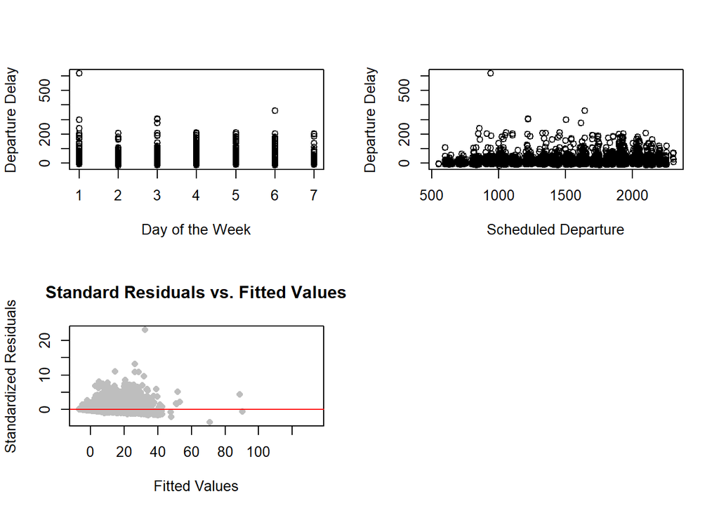

```r
# Code to perform Goodness of Fit Analysis...
par(mfrow=c(2,2))
# Linearity Assumption
plot(atlanta_flights_new$DAY_OF_WEEK,atlanta_flights_new$DEPARTURE_DELAY,
ylab = "Departure Delay", xlab = "Day of the Week")
plot(atlanta_flights_new$SCHEDULED_DEPARTURE,atlanta_flights_new$DEPARTURE_DELAY,
ylab = "Departure Delay", xlab = "Scheduled Departure")

# Constant Variance and Independence Assumptions
standardized.residuals = rstandard(model3)
fitted.values = model3$fitted.values
plot(fitted.values,standardized.residuals, main="Standard Residuals vs. Fitted Values",
xlab="Fitted Values", ylab="Standardized Residuals", col= "gray", pch = 16)
abline(h=0, col="Red")

# Normality Assumption
par(mfrow=c(1,2))
```

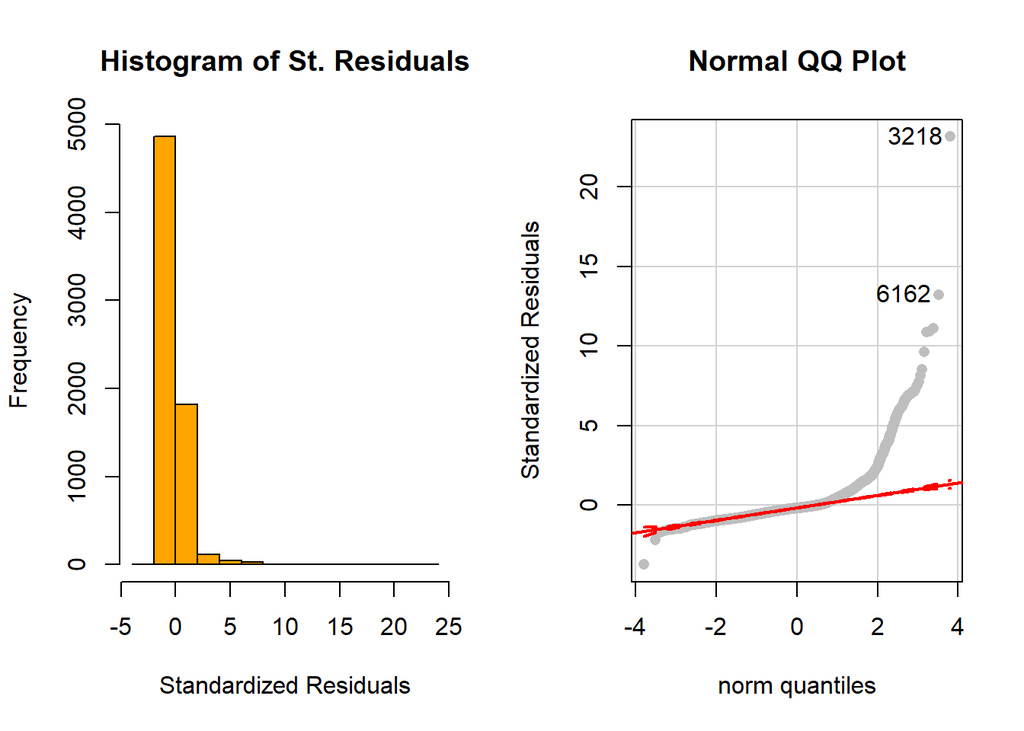

```
## 3218 6162
## 3217 6161
```

```r
# histogram
hist(standardized.residuals, col = 'orange', main = 'Histogram of St. Residuals',
xlab = "Standardized Residuals")
# q-q plot
library(car)
## Loading required package: carData
qqPlot(standardized.residuals, main = 'Normal QQ Plot', ylab = "Standardized Residuals",
col = 'gray', col.line = 'red', pch = 16)
```

**Response to Question 6**:  
Linearity: There is no clear non-linear trend apparent on the above scatterplots. The linear relationship between these variables and the response variable seems to be weak.

Constant Variance: Based on the standardized residuals vs. fitted values we can conclude that the constant variance assumption does not hold for this data. There are a few negative values (flights that actually left before their scheduled departure), however, overall the residuals are definitely skewed higher.

Independence: Again, based on the standardized residuals vs. fitted values we can conclude that the independence assumption probably does not hold for this data. Although this assumption is much more difficult to really check, we can see that there appears to be some correlation in the fitted values based on the way that they are all clumped together in the first third of the plot area.

Normality: Based on the Q-Q Norm plot, we can see that our data is not exactly normally distributed. There are very heavy tails on the upper side, and it appears that there is at least one outlier still as well.

### Question 7 - Confidence Interval

What is the 99% confidence interval for the estimated regression coefficient for day of the week?

```r
confint(model3, parm="DAY_OF_WEEK", level=0.99, type="confidence")
```

```
##                  0.5 %       99.5 %
## DAY_OF_WEEK -0.9302243 -0.007901542
```

**Response to Question 7**:  
See code

### Question 8 - Conclusion

What can you infer about the reliability of *model3*? What can you conclude about flight delays at the Atlanta airport based on this information?

**Response to Question 8**:  
Based on the R-squared values, we can see that this model does not do a very good job in explaining the variability in the data. Based on this knowledge, we can probably say that flight delays at the Atlanta airport cannot be easily predicted given the data we have. Perhaps there are other factors or variables at play that were not included in this dataset.

### Question 9 - Suggestions

What are your suggestions or curiosities about other potential ways to model flight delays at the Atlanta airport?

**Response to Question 9**:  
Pretty open ended question, a few possible answers include:  
*Explore a logistic regression to check whether or not a flight will be delayed;*  
Research other types of regression (gamma family, etc) to try to better explain the data;  
*Include other variables (such as weather/precipitation for ATL and destination airport), etc.

# Part 2: Logistic Regression

## Data Set Background

The data analyzed in the second part of the exam came from medical patients who have suffered from a heart attack within the past year.

The **response variable** is ‘still_alive’ which is a binary variable indicating if the patient is still living or not (0=dead, 1=alive).

The **predicting variables** are as follows:

*survival – the number of months a patient survived (has survived, if patient is still alive).

*age – age in years when heart attack occurred

*pericardial-effusion – Pericardial effusion is fluid around the heart. This is a binary variable: 0=no fluid, 1=fluid.

*fractional-shortening – a measure of contracility around the heart. Lower numbers are increasingly abnormal

*lvdd – left ventricular end-diastolic dimension. This is a measure of the size of the heart at end-diastole. Large hearts tend to be sick hearts.

## Read Data

Read the data and answer the questions below. Assume a *significance threshold of 0.05* for hypothesis tests.

```r
# Read the data set
echo = read.csv('echo.csv', header=TRUE, sep=",")

# Viewing first few rows of data
head(echo)
```

```
##   age survival still_alive pericardial_effusion fractional_shortening  lvdd
## 1  71       11           1                    0                 0.260 4.600
## 2  72       19           1                    0                 0.380 4.100
## 3  55       16           1                    0                 0.260 3.420
## 4  60       57           1                    0                 0.253 4.603
## 5  57       19           0                    0                 0.160 5.750
## 6  68       26           1                    0                 0.260 4.310
```

## Short Answer Questions

### Question 1: Exploratary Analysis

Plot the boxplots to describe the relationship between the response (still_alive) and the following predicting variables: age, survival, fractional_shortening, and lvdd. Provide the R code and plots generated.

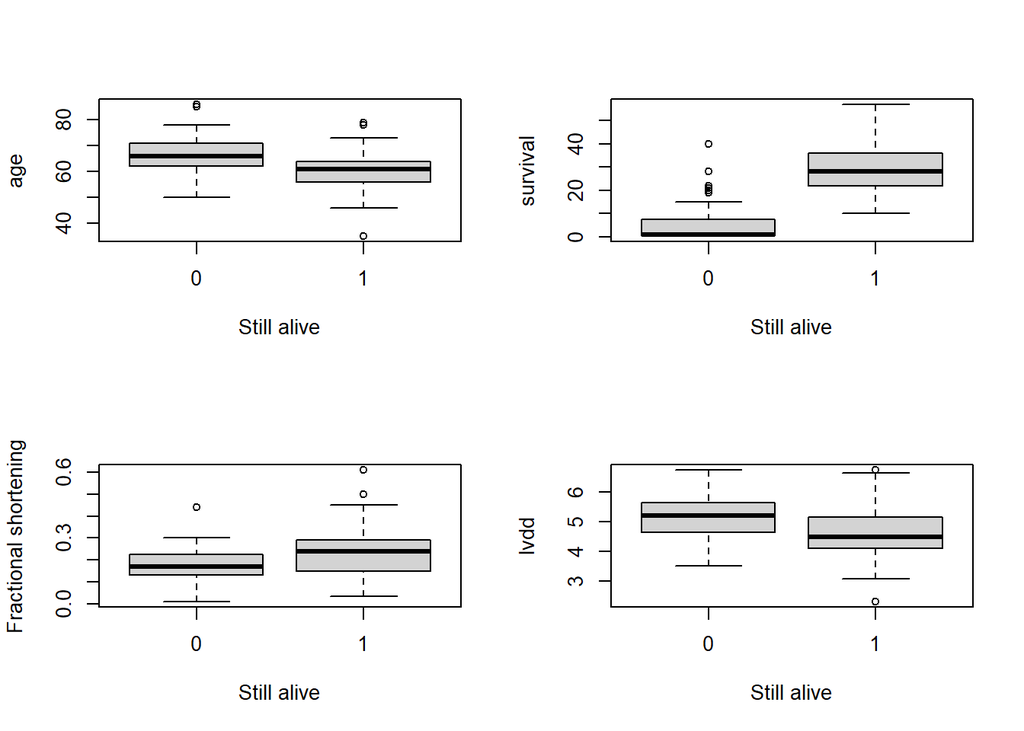

```r
# Code to create the boxplots...
par(mfrow=c(2,2))
boxplot(age ~ still_alive,data=echo, ylab = "age",xlab ="Still alive")
boxplot(survival ~ still_alive,data=echo, ylab = "survival",xlab ="Still alive")
boxplot(fractional_shortening ~ still_alive,data=echo,ylab = "Fractional shortening",xlab ="Still alive")
boxplot(lvdd ~ still_alive,data=echo,ylab = "lvdd",xlab ="Still alive")
```

**Response to Question 1**: From the boxplots we can see there are obvious differences of median values for the age, survival, fractional_shortening and lvdd, and the response value is binary data type, thus it is reasonable to use logistic regression for the dataset.

### Question 2: Model Fitting

Create a model using the following predicting variables: age, fractional_shortening, and lvdd (exclude survival due to potential multicollinearity with the response variable, ‘still_alive’). What are the model parameters and what are their estimates? Which of them are statistically significant at the 95% confidence level?

```r
# Code to create the logistic model...
loggmodel = glm(still_alive ~ age + fractional_shortening + lvdd , family = "binomial", data=echo)
summary(loggmodel)
```

```
##
## Call:
## glm(formula = still_alive ~ age + fractional_shortening + lvdd,
##     family = "binomial", data = echo)
##
## Deviance Residuals:
##     Min       1Q   Median       3Q      Max
## -2.2786  -0.9117   0.5067   0.7823   1.9792
##
## Coefficients:
##                       Estimate Std. Error z value Pr(>|z|)
## (Intercept)            8.54944    2.71445   3.150  0.00163 **
## age                   -0.08984    0.03162  -2.841  0.00450 **
## fractional_shortening  5.90295    2.85481   2.068  0.03867 *
## lvdd                  -0.65886    0.32327  -2.038  0.04153 *
## ---
## Signif. codes:  0 '***' 0.001 '**' 0.01 '*' 0.05 '.' 0.1 ' ' 1
##
## (Dispersion parameter for binomial family taken to be 1)
##
##     Null deviance: 132.21  on 106  degrees of freedom
## Residual deviance: 107.12  on 103  degrees of freedom
## AIC: 115.12
##
## Number of Fisher Scoring iterations: 5
```

**Response to Question 2**: Model parameters and their estimates: (Intercept) 8.54944 age -0.08984 fractional_shortening 5.90295 lvdd -0.65886 Model parameters that are statistically significant at the 95% confidence level include: intercept, age, fractional_shortening, and lvdd as the p value for all of them are smaller than 0.05 as shown in the model summary.

### Question 3: Parameter Interpretation

Interpret the estimated value of the parameter corresponding to *age* in the context of this problem.

**Response to Question 3**: For a one unit increase in the age of the patient, the log-odds of the patient still being alive decrease by 0.08984, holding all other variables constant.

In the same way, for a one unit increase in the age of the patient, the odds of the patient still being alive change by a factor of e−0.08984 = 0.91407742596, holding all other variables constant. Don’t forget to include the phrase “holding all other variables constant”!

### Question 4: Model Equation

Provide the equation for the estimated logit transformation of the probability of still being alive given the predicting variables.

**Response to Question 4**:  
Let pi be the probability of still being alive given the predicting variables, then the equation for the estimated logit transformation of the probability of still being alive given the predicting variables is: log(p/(1-p)) = 8.54944 − 0.08984 X_age + 5.90295 X_fract − 0.65886 X_lvdd

### Question 5: Parameter Interpretation 2

How does the log-odds change with a 1 unit increase in fractional_shortening, holding all other variables constant?

**Response to Question 5**: The regression coefficient estimate for the fractional_shortening parameter is 5.90295, which mean with one unit increase in fractional_shortening, holding all other variable constant, the log_odds will increase by 5.90295.

### Question 6: Deviances

What is the null deviance and its degree of freedom? What is the approximated distribution of residual deviance? What is the AIC for your model?

```r
loggmodel$null.deviance
```

```
## [1] 132.2142
```

```r
dim(echo)[1]-1
```

```
## [1] 106
```

```r
loggmodel$aic
```

```
## [1] 115.1188
```

**Response to Question 6**: The null deviance is 132.21 and its degrees of freedom is 106.  
The residual deviance distribution is ChiSquared.  
The AIC for the model is 115.1188.

**The End.**